# Association rules

Movie recommender systems

Benyamin Jmai Al Ahmadi

2018-07-20 15:53:28

> با استفاده از داده نظرهای فیلم به سوالات زیر پاسخ دهید.

```r
library(readr)
library(dplyr)
library(stringr)
library(highcharter)
library(wordcloud2)
library(tm)
library(arules)
library(arulesViz)
library(ggplot2)
library(tidyr)

# Movies
seperatedgenre = data.frame()
movie = read_lines('../data/movies.dat') %>% str_replace_all('::','$') %>% str_replace_all('\"',' ') %>% paste(collapse = '\n') %>% read_delim(delim = "$",col_names = c("MovieID","Title","Genres"))

movie$year = movie$Title %>% substr(nchar(.)-4,nchar(.)-1)
movie = movie %>% filter(year %>% as.numeric() > '1000' & year %>% as.numeric() < '3000')
movie$year = as.numeric(movie$year)

for(i in 1:nrow(movie)){
  for(t in str_split(movie$Genres[i],pattern = "\\|")[[1]]){
    seperatedgenre = rbind(seperatedgenre,movie[i,] %>% mutate(Genres = t))
  }
}

tag = read_delim('../data/tags.dat',delim = "::" ,col_names = c("UserID",NA,"MovieID",NA,"Tag",NA,"Time")) %>% select(1,3,5,7)

rating = read_delim('../data/ratings.dat',delim = "::" ,col_names = c("UserID",NA,"MovieID",NA,"Rating",NA,"Timestamp")) %>% select(1,3,5,7)
```

۱. آماره های زیر را بیابید. الف. محبوب ترین فیلم کدام است؟ ب. بیشترین نظرات درباره چه فیلمی داده شده است؟ پ. منفورترین فیلم کدام است؟ ت. تعداد فیلم های ساخته شده در هر سال ث. در هر سالی مردم به چه ژانری علاقه مند بوده اند.

```r
rating %>% group_by(MovieID) %>% summarise(averate = mean(Rating),sumrate = sum(Rating), countrate = n()) %>% left_join(movie,by="MovieID") -> t1
print("Most Popular")
```

```
## [1] "Most Popular"
```

```r
t1 %>% arrange(-sumrate) %>% head(5)
```

```
## # A tibble: 5 x 7
##   MovieID averate sumrate countrate Title                 Genres      year
##     <int>   <dbl>   <dbl>     <int> <chr>                 <chr>      <dbl>
## 1     296    4.16 144944.     34864 Pulp Fiction (1994)   Comedy|Cr~  1994
## 2     593    4.20 141547      33668 Silence of the Lambs~ Crime|Hor~  1991
## 3     318    4.46 138736      31126 Shawshank Redemption~ Drama       1994
## 4     356    4.01 138296      34457 Forrest Gump (1994)   Comedy|Dr~  1994
## 5     260    4.22 120554.     28566 Star Wars: Episode I~ Action|Ad~  1977
```

```r
print("Most Rated")
```

```
## [1] "Most Rated"
```

```r
t1 %>% arrange(-countrate) %>% head(5)
```

```
## # A tibble: 5 x 7
##   MovieID averate sumrate countrate Title            Genres           year
##     <int>   <dbl>   <dbl>     <int> <chr>            <chr>           <dbl>
## 1     296    4.16 144944.     34864 Pulp Fiction (1~ Comedy|Crime|D~  1994
## 2     356    4.01 138296      34457 Forrest Gump (1~ Comedy|Drama|R~  1994
## 3     593    4.20 141547      33668 Silence of the ~ Crime|Horror|T~  1991
## 4     480    3.66 119480.     32631 Jurassic Park (~ Action|Adventu~  1993
## 5     318    4.46 138736      31126 Shawshank Redem~ Drama            1994
```

```r
print("Least Popular")
```

```
## [1] "Least Popular"
```

```r
rating %>% group_by(MovieID) %>% filter(Rating < 2.5) %>% summarise(averate = mean(Rating),sumrate = sum(Rating), countrate = n()) %>% left_join(movie,by="MovieID") %>% arrange(-countrate) %>% head(5)
```

```
## # A tibble: 5 x 7
##   MovieID averate sumrate countrate Title             Genres          year
##     <int>   <dbl>   <dbl>     <int> <chr>             <chr>          <dbl>
## 1     344    1.50   8321       5546 Ace Ventura: Pet~ Comedy          1994
## 2     231    1.43   7550.      5268 Dumb & Dumber (1~ Comedy          1994
## 3     153    1.62   7720.      4753 Batman Forever (~ Action|Advent~  1995
## 4      19    1.43   6715       4712 Ace Ventura: Whe~ Comedy          1995
## 5     208    1.52   6791       4462 Waterworld (1995) Action|Advent~  1995
```

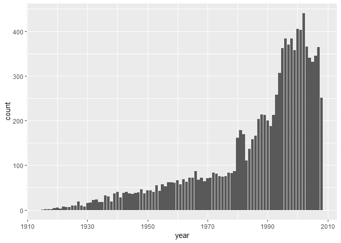

```r
movie %>% group_by(year) %>% summarise(count = n()) %>% ggplot(aes(x = year , y = count)) + geom_bar(stat = "identity")
```

```r
left_join(t1,seperatedgenre,by = "MovieID") %>% group_by(year.y,Genres.y) %>% summarise(averate = mean(averate)) %>% ungroup() -> t1
t1 %>% group_by(year.y) %>% summarise(averate = max(averate)) %>% merge(t1) %>% filter(!is.na(year.y))
```

```
##     year.y  averate    Genres.y
## 1     1915 3.248768       Drama
## 2     1915 3.248768         War
## 3     1916 3.789474       Drama
## 4     1917 3.828571      Comedy
## 5     1918 3.575000      Comedy
## 6     1919 3.412698     Romance
## 7     1920 3.960526   Film-Noir
## 8     1920 3.960526       Crime
## 9     1921 3.865471      Comedy
## 10    1922 3.733333 Documentary
## 11    1923 3.974074      Action
## 12    1923 3.974074     Romance
## 13    1924 4.110687     Romance
## 14    1925 4.115610     Romance
```

[output cut: 86 more lines]

۲. ژانر فیلم ها را استخراج نمایید. سپس آماره های زیر را استخراج نمایید. الف. نمودار ستونی تعداد فیلم های هر ژانر ب. نمودار همبستگی ژانرها پ. متوسط امتیاز به هر ژانر ت. دوران طلایی فیلم سازی

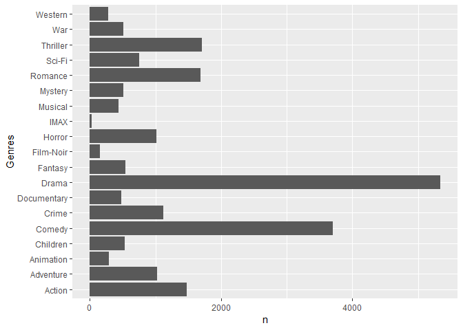

```r
seperatedgenre %>% count(Genres) %>% filter(n > 2) %>% ggplot(aes(x = Genres, y = n)) + geom_bar(stat = "identity") + coord_flip()
```

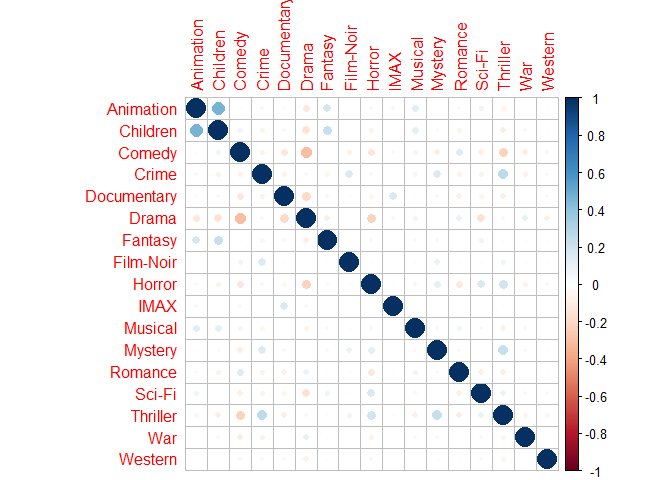

```r
seperatedgenre %>% mutate(t = 1) %>% spread(Genres,t) %>% .[,-c(1,2,3,4,5,6)] %>% sapply(function(x) ifelse(is.na(x),0,x)) %>%
  cor() %>% corrplot::corrplot(method = 'circle')
```

```r
rating %>% filter(!is.na(Rating)) %>% group_by(MovieID) %>% summarise(averate = mean(Rating,na.rm=T)) %>%
  right_join(seperatedgenre,by = "MovieID") %>% filter(MovieID != 25942) %>% group_by(Genres) %>% summarise(averate = mean(averate,rm.na=T), cnt = n()) %>% filter(cnt > 10)
```

```
## # A tibble: 19 x 3
##    Genres      averate   cnt
##    <chr>         <dbl> <int>
##  1 Action         3.06  1473
##  2 Adventure      3.16  1025
##  3 Animation      3.24   286
##  4 Children       3.00   527
##  5 Comedy         3.12  3699
##  6 Crime         NA     1118
##  7 Documentary   NA      481
##  8 Drama         NA     5337
##  9 Fantasy        3.20   543
## 10 Film-Noir      3.71   148
## 11 Horror         2.80  1013
## 12 IMAX           3.28    29
## 13 Musical        3.26   436
## 14 Mystery        3.33   509
## 15 Romance        3.30  1684
## 16 Sci-Fi         2.97   754
## 17 Thriller      NA     1706
## 18 War           NA      511
## 19 Western        3.31   275
```

```r
rating %>% filter(!is.na(Rating)) %>% group_by(MovieID) %>% summarise(averate = mean(Rating,na.rm=T)) %>%
  right_join(movie,by = "MovieID") %>% filter(MovieID != 25942) %>% group_by(year) %>% summarise(averate = mean(averate,rm.na=T)) %>%
  arrange(-averate)
```

```
## # A tibble: 94 x 2
##     year averate
##    <dbl>   <dbl>
##  1  1924    3.91
##  2  1931    3.71
##  3  1921    3.67
##  4  1938    3.65
##  5  1946    3.64
##  6  1941    3.63
##  7  1939    3.62
##  8  1932    3.61
##  9  1916    3.60
## 10  1929    3.60
## # ... with 84 more rows
```

۳. نمودار ابر لغات را بر حسب کلمات عنوان فیلم ها رسم نمایید.

```r
paste0('\\b', stopwords('en')%>% c('s','d') %>% paste(collapse = '\\b|\\b') , '\\b') -> stopwords
movie$Title %>% str_sub(1,-7) %>% tolower() %>% str_replace_all("[:punct:]"," ") %>% str_remove_all(stopwords) %>%
  str_split("\\s+") %>% unlist() %>% .[which(. != "")] %>% as.data.frame(stringAsFactor = F) %>% select(word = 1) %>% filter(str_length(word) > 2) %>% count(word)  %>% arrange(-n) %>% head(300) %>% wordcloud2(size = 1)
```

[interactive chart not shown]

۴. با استفاده از قوانین همبستگی یک توصیه گر برای فیلم ها بسازید. شبیه ترین فیلم ها به لیست زیر را پیدا کنید.

- Castle in the Sky (1986)
- Cast Away (2000)
- No Country for Old Men (2007)
- Memento (2000)

```r
rating %>% select(MovieID,UserID) -> t4
split(t4$MovieID,t4$UserID) %>% as("transactions") %>%
  apriori(parameter = list(  supp = 0.001,  conf = 0.6,  maxlen = 2,  minlen = 2)) %>% DATAFRAME() -> apriori
```

```
## Apriori
##
## Parameter specification:
##  confidence minval smax arem  aval originalSupport maxtime support minlen
##         0.6    0.1    1 none FALSE            TRUE       5   0.001      2
##  maxlen target   ext
##       2  rules FALSE
##
## Algorithmic control:
##  filter tree heap memopt load sort verbose
##     0.1 TRUE TRUE  FALSE TRUE    2    TRUE
##
## Absolute minimum support count: 69
##
## set item appearances ...[0 item(s)] done [0.00s].
## set transactions ...[10677 item(s), 69878 transaction(s)] done [1.72s].
## sorting and recoding items ... [6605 item(s)] done [0.41s].
## creating transaction tree ... done [0.10s].
## checking subsets of size 1 2
```

```
##  done [6.22s].
## writing ... [455988 rule(s)] done [0.26s].
## creating S4 object  ... done [0.14s].
```

```r
apriori$LHS = apriori$LHS %>% str_sub(2,-2) %>% as.numeric()
apriori$RHS = apriori$RHS %>% str_sub(2,-2) %>% as.numeric()

paste("* Castle in the Sky (1986)")
```

```
## [1] "* Castle in the Sky (1986)"
```

```r
apriori %>% filter(LHS == 6350) %>% left_join(movie,by = c("RHS" = "MovieID")) %>% arrange(-lift) %>%
  select(Title,support,confidence,lift) %>% head()
```

```
##                                                  Title    support
## 1         My Neighbor Totoro (Tonari no Totoro) (1988) 0.01024643
## 2             Princess Mononoke (Mononoke-hime) (1997) 0.01299408
## 3 Spirited Away (Sen to Chihiro no kamikakushi) (2001) 0.01445376
## 4                              Incredibles, The (2004) 0.01084748
## 5                             Kill Bill: Vol. 1 (2003) 0.01106214
## 6         Eternal Sunshine of the Spotless Mind (2004) 0.01038954
##   confidence      lift
## 1  0.6135390 26.415821
## 2  0.7780634 13.180488
## 3  0.8654670 12.508191
## 4  0.6495287  5.645245
## 5  0.6623822  5.231232
## 6  0.6221080  5.179514
```

```r
paste("* Cast Away (2000)")
```

```
## [1] "* Cast Away (2000)"
```

```r
apriori %>% filter(LHS == 4022) %>% left_join(movie,by = c("RHS" = "MovieID")) %>% arrange(-lift) %>%
  select(Title,support,confidence,lift) %>% head()
```

```
##                                                       Title    support
## 1                                          Gladiator (2000) 0.09688314
## 2   Crouching Tiger, Hidden Dragon (Wu hu zang long) (2000) 0.07946707
## 3                                              X-Men (2000) 0.07893758
## 4                                              Shrek (2001) 0.08642205
## 5 Lord of the Rings: The Fellowship of the Ring, The (2001) 0.08617877
## 6                                         Fight Club (1999) 0.08264404
##   confidence     lift
## 1  0.7391637 3.341611
## 2  0.6062889 3.231106
## 3  0.6022492 3.201032
## 4  0.6593515 3.170313
## 5  0.6574954 2.882699
## 6  0.6305274 2.697440
```

```r
paste("* No Country for Old Men (2007)")
```

```
## [1] "* No Country for Old Men (2007)"
```

```r
apriori %>% filter(LHS == 55820) %>% left_join(movie,by = c("RHS" = "MovieID")) %>% arrange(-lift) %>%
  select(Title,support,confidence,lift) %>% head()
```

```
##                                          Title    support confidence
## 1                         Departed, The (2006) 0.02408483  0.6980506
## 2                              Sin City (2005) 0.02209565  0.6403982
## 3                         Batman Begins (2005) 0.02236755  0.6482787
## 4                     Kill Bill: Vol. 2 (2004) 0.02226738  0.6453754
## 5 Eternal Sunshine of the Spotless Mind (2004) 0.02460002  0.7129822
## 6                          Donnie Darko (2001) 0.02106529  0.6105350
##        lift
## 1 11.768005
## 2  7.648221
## 3  6.799823
## 4  5.969231
## 5  5.936110
## 6  5.904909
```

```r
paste("* Memento (2000)")
```

```
## [1] "* Memento (2000)"
```

```r
apriori %>% filter(LHS == 4226) %>% left_join(movie,by = c("RHS" = "MovieID")) %>% arrange(-lift) %>%
  select(Title,support,confidence,lift) %>% head()
```

```
##                                                       Title   support
## 1 Lord of the Rings: The Fellowship of the Ring, The (2001) 0.1310570
## 2             Lord of the Rings: The Two Towers, The (2002) 0.1163456
## 3                                              Shrek (2001) 0.1153010
## 4                                         Fight Club (1999) 0.1292682
## 5                                          Gladiator (2000) 0.1122957
## 6                                   Sixth Sense, The (1999) 0.1256046
##   confidence     lift
## 1  0.7104181 3.114732
## 2  0.6306726 3.062766
## 3  0.6250097 3.005190
## 4  0.7007214 2.997736
## 5  0.6087193 2.751898
## 6  0.6808626 2.452439
```

۵. تمرین سخت: در گیت هاب برای خود اکانت درست کنید. همه تمرین های خود را آنجا بارگذاری کنید! و لینک آن را ارسال نمایید.

https://github.com/benyaminjami1376/Data-Analysis-course ***

۶. پنج انتقاد از درس و نحوه تدریس را بیان کنید.

زمان کلاس اگ دیرتز میبود بهتر بود. امتحانات و تمارین هیچ ارتباطی به هم نداشتند و اصلا نمشد فهمید که برای امتحان چه چیزی باید مطالعه شود و شاید بهتر بود که امتحان عملی گرفته شود. انجام بعضی تمارین با توجه به حجم داده و محاسبات بسیار سخت بود و لپ تاب من جوابگو نبود. گنگ بودن بعضی سوالات تمارین. تصحیح نشدن هیچ کدام از تمارین و امتحانات در طول ترم.

۷. پنج پیشنهاد برای بهتر شدن درس بیان کنید.

ندادن نمونه سوال برای پابان ترم و میان ترم با توجه به تفاوت بسیار نمونه سوالات با خود امتحان امسال. ارائه پاسخ برای تمارین. تغییر زبان برنامه نویسی به پابتون. تصحیح تمارین به صورت پیوسته. امکان انجام گروهی پروژه.

۸. سه موضوع آماری جدید برای جایگزینی در سرفصل ها پیشنهاد دهید.

neural network hidden markov model

۹. سه داده جالب برای کار در کلاس پیشنهاد دهید.

داده ترافیک شهری داده های بایو داده های موسیقی

۱۰. چهار نکته مهمی که در کلاس یاد گرفتید را بیان کنید.

آزمون فرض تصویر سازی PCA خوشه بندی